# 本次实验选用Wine Reviews的两个库进行关联规则和频繁模式挖掘

```python
import numpy as np
import pandas as pd
import matplotlib.pyplot as plt
from scipy.spatial.distance import pdist
from math import ceil

from collections import defaultdict
%matplotlib inline
data1 = pd.read_csv("Wine/winemag-data_first150k.csv",encoding="utf-8")[
    ["country", "points", "price", "province", "variety", "winery"]
]
data2 = pd.read_csv("Wine/winemag-data-130k-v2.csv",encoding="utf-8")[
    ["country", "points", "price", "province", "variety", "winery"]
]
```

并非所有属性都是有意义的属性，这里剔除了一些数据库中的无用属性，保留country points，price，province，variety，winery这几个属性。 并且除去一些index和title，只保留数据。

```python
#剔除缺失值
data1_1=data1
data2_1=data2
data1_1=data1_1.dropna(axis=0, how='any')
data1_1=data1_1.reset_index(drop=True)#index重排序
data2_1=data2_1.dropna(axis=0, how='any')
data2_1=data2_1.reset_index(drop=True)

max1_1=data1_1[["points"][0]].max()
min1_1=data1_1[["points"][0]].min()
#将价格离散化，分成高，中，低三份，分别命名high,middle,low,因为价格差距较大，手动设置阈值为100,1000
middle_price1=100
middle_price2=1000
#度数同理离散化，平均分成三份
middle_point1=min1_1+(max1_1-min1_1)/3#库1库2值分布不多，可以用同一个
middle_point2=min1_1+2*(max1_1-min1_1)/3


price_array=data1_1["price"].values
price_label=[]
price_array2=data2_1["price"].values
price_label2=[]

point_array=data1_1["points"].values
point_label=[]
point_array2=data2_1["points"].values
point_label2=[]
#库1price
for i in range((data1_1["price"].shape[0])):
    if(price_array[i]<middle_price1):
        price_label.append('cheap')

    elif(middle_price1<=price_array[i] and price_array[i]<middle_price2):
        price_label.append('general')

    else:
        price_label.append('expensive')
#库2price
for i in range((data2_1["price"].shape[0])):
    if(price_array2[i]<middle_price1):
        price_label2.append('cheap')

    elif(middle_price1<=price_array2[i] and price_array2[i]<middle_price2):
        price_label2.append('general')

    else:
        price_label2.append('expensive')

#将更改后的值写回两个库 的dataframe中
price_label= pd.DataFrame(price_label)
price_label.columns=['price']
data1_1['price'] = price_label['price']

price_label2= pd.DataFrame(price_label2)
price_label2.columns=['price']
data2_1['price'] = price_label2['price']

#库1points
for i in range((data1_1["points"].shape[0])):
    if(point_array[i]<middle_point1):
        point_label.append('high')
    elif(middle_point1<=point_array[i] and point_array[i]<middle_point2):
        point_label.append('middle')
    else:
        point_label.append('low')
#库2points
for i in range((data2_1["points"].shape[0])):
    if(point_array2[i]<middle_point1):
        point_label2.append('high')
    elif(middle_point1<=point_array2[i] and point_array2[i]<middle_point2):
        point_label2.append('middle')
    else:
        point_label2.append('low')

point_label= pd.DataFrame(point_label)
point_label.columns=['points']
data1_1['points'] = point_label['points']

point_label2= pd.DataFrame(point_label2)
point_label2.columns=['points']
data2_1['points'] = point_label2['points']

data1_1.to_csv("1_after_delete.csv",header=False,index=False)
data2_1.to_csv("2_after_delete.csv",header=False,index=False)
```

对wine reviews的两个数据库进行频繁模式和关联规则挖掘，使用的算法为Apriori.之后导出频繁模式和关联规则，并计算支持度(Support)和置信度(Confidence)

```python
#对数据库1
inFile = apriori.dataFromFile('1_after_delete.csv')#读取csv文件
minSupport =0.15 #最小支持度minS
minConfidence =0.6#最小置信度minC

items, rules = apriori.runApriori(inFile, minSupport, minConfidence)#利用apriori算法找出频繁模式和关联规则挖掘

apriori.printResults(items, rules)#导出频繁模式和关联规则，并计算支持度和置信度
```

```
------------------------ Frequence Items:
item: ('high', 'US', 'cheap') ,Support: 0.164
item: ('US', 'high') ,Support: 0.164
item: ('cheap', 'California', 'middle') ,Support: 0.174
item: ('middle', 'cheap', 'California', 'US') ,Support: 0.174
item: ('California', 'middle') ,Support: 0.179
item: ('US', 'California', 'middle') ,Support: 0.179
item: ('US', 'cheap', 'middle') ,Support: 0.262
item: ('US', 'middle') ,Support: 0.267
item: ('California', 'cheap') ,Support: 0.315
item: ('US', 'cheap', 'California') ,Support: 0.315
item: ('California',) ,Support: 0.323
item: ('US', 'California') ,Support: 0.323
item: ('high', 'cheap') ,Support: 0.350
item: ('high',) ,Support: 0.351
item: ('US', 'cheap') ,Support: 0.444
item: ('US',) ,Support: 0.453
item: ('cheap', 'middle') ,Support: 0.592
item: ('middle',) ,Support: 0.609
item: ('cheap',) ,Support: 0.970

------------------------ RULES:
Rule: ('cheap',) ==> ('middle',) ,Confidence: 0.611, Support:0.592
Rule: ('US', 'middle') ==> ('California', 'cheap') ,Confidence: 0.654, Support:0.174
Rule: ('US', 'cheap', 'middle') ==> ('California',) ,Confidence: 0.666, Support:0.174
Rule: ('US', 'middle') ==> ('California',) ,Confidence: 0.671, Support:0.179
Rule: ('US',) ==> ('California', 'cheap') ,Confidence: 0.695, Support:0.315
Rule: ('US', 'cheap') ==> ('California',) ,Confidence: 0.710, Support:0.315
Rule: ('US',) ==> ('California',) ,Confidence: 0.714, Support:0.323
Rule: ('middle',) ==> ('cheap',) ,Confidence: 0.973, Support:0.592
Rule: ('California',) ==> ('cheap',) ,Confidence: 0.974, Support:0.315
Rule: ('California',) ==> ('US', 'cheap') ,Confidence: 0.974, Support:0.315
Rule: ('US', 'California') ==> ('cheap',) ,Confidence: 0.974, Support:0.315
Rule: ('California', 'middle') ==> ('cheap',) ,Confidence: 0.975, Support:0.174
Rule: ('California', 'middle') ==> ('US', 'cheap') ,Confidence: 0.975, Support:0.174
Rule: ('US', 'California', 'middle') ==> ('cheap',) ,Confidence: 0.975, Support:0.174
Rule: ('US',) ==> ('cheap',) ,Confidence: 0.980, Support:0.444
Rule: ('US', 'middle') ==> ('cheap',) ,Confidence: 0.982, Support:0.262
Rule: ('US', 'high') ==> ('cheap',) ,Confidence: 0.997, Support:0.164
Rule: ('high',) ==> ('cheap',) ,Confidence: 0.997, Support:0.350
Rule: ('California',) ==> ('US',) ,Confidence: 1.000, Support:0.323
Rule: ('California', 'cheap') ==> ('US',) ,Confidence: 1.000, Support:0.315
Rule: ('California', 'middle') ==> ('US',) ,Confidence: 1.000, Support:0.179
Rule: ('California', 'cheap', 'middle') ==> ('US',) ,Confidence: 1.000, Support:0.174
```

库1： 在支持度和置信度分别设置为0.15,0.6的前提下，一共挖掘了19个频繁项集，22条关联规则。

```python
#对数据库2
inFile2 = apriori.dataFromFile('2_after_delete.csv')#读取csv文件
minSupport2 =0.15 #最小支持度minS
minConfidence2 =0.6#最小置信度minC

items2, rules2= apriori.runApriori(inFile2, minSupport2, minConfidence2)#利用apriori算法找出频繁模式和关联规则挖掘

apriori.printResults(items2, rules2)#导出频繁模式和关联规则，并计算支持度和置信度
```

```
------------------------ Frequence Items:
item: ('cheap', 'California', 'middle') ,Support: 0.196
item: ('middle', 'California', 'cheap', 'US') ,Support: 0.196
item: ('California', 'middle') ,Support: 0.201
item: ('US', 'California', 'middle') ,Support: 0.201
item: ('high', 'cheap') ,Support: 0.268
item: ('high',) ,Support: 0.269
item: ('California', 'cheap') ,Support: 0.289
item: ('US', 'cheap', 'California') ,Support: 0.289
item: ('California',) ,Support: 0.299
item: ('US', 'California') ,Support: 0.299
item: ('US', 'cheap', 'middle') ,Support: 0.304
item: ('US', 'middle') ,Support: 0.310
item: ('US', 'cheap') ,Support: 0.438
item: ('US',) ,Support: 0.449
item: ('cheap', 'middle') ,Support: 0.666
item: ('middle',) ,Support: 0.685
item: ('cheap',) ,Support: 0.967

------------------------ RULES:
Rule: ('US', 'middle') ==> ('cheap', 'California') ,Confidence: 0.632, Support:0.196
Rule: ('US',) ==> ('California', 'cheap') ,Confidence: 0.644, Support:0.289
Rule: ('US', 'cheap', 'middle') ==> ('California',) ,Confidence: 0.645, Support:0.196
Rule: ('US', 'middle') ==> ('California',) ,Confidence: 0.650, Support:0.201
Rule: ('California',) ==> ('cheap', 'middle') ,Confidence: 0.656, Support:0.196
Rule: ('California',) ==> ('US', 'cheap', 'middle') ,Confidence: 0.656, Support:0.196
Rule: ('US', 'California') ==> ('cheap', 'middle') ,Confidence: 0.656, Support:0.196
Rule: ('US', 'cheap') ==> ('California',) ,Confidence: 0.660, Support:0.289
Rule: ('US',) ==> ('California',) ,Confidence: 0.665, Support:0.299
Rule: ('California',) ==> ('middle',) ,Confidence: 0.674, Support:0.201
Rule: ('California',) ==> ('US', 'middle') ,Confidence: 0.674, Support:0.201
Rule: ('US', 'California') ==> ('middle',) ,Confidence: 0.674, Support:0.201
Rule: ('US',) ==> ('cheap', 'middle') ,Confidence: 0.676, Support:0.304
Rule: ('California', 'cheap') ==> ('middle',) ,Confidence: 0.677, Support:0.196
Rule: ('cheap', 'California') ==> ('US', 'middle') ,Confidence: 0.677, Support:0.196
Rule: ('cheap', 'US', 'California') ==> ('middle',) ,Confidence: 0.677, Support:0.196
Rule: ('cheap',) ==> ('middle',) ,Confidence: 0.689, Support:0.666
Rule: ('US',) ==> ('middle',) ,Confidence: 0.690, Support:0.310
Rule: ('US', 'cheap') ==> ('middle',) ,Confidence: 0.693, Support:0.304
Rule: ('California',) ==> ('cheap',) ,Confidence: 0.968, Support:0.289
Rule: ('California',) ==> ('US', 'cheap') ,Confidence: 0.968, Support:0.289
Rule: ('US', 'California') ==> ('cheap',) ,Confidence: 0.968, Support:0.289
Rule: ('California', 'middle') ==> ('cheap',) ,Confidence: 0.973, Support:0.196
Rule: ('California', 'middle') ==> ('US', 'cheap') ,Confidence: 0.973, Support:0.196
Rule: ('US', 'California', 'middle') ==> ('cheap',) ,Confidence: 0.973, Support:0.196
Rule: ('middle',) ==> ('cheap',) ,Confidence: 0.973, Support:0.666
Rule: ('US',) ==> ('cheap',) ,Confidence: 0.976, Support:0.438
Rule: ('US', 'middle') ==> ('cheap',) ,Confidence: 0.980, Support:0.304
Rule: ('high',) ==> ('cheap',) ,Confidence: 0.997, Support:0.268
Rule: ('California',) ==> ('US',) ,Confidence: 1.000, Support:0.299
Rule: ('California', 'middle') ==> ('US',) ,Confidence: 1.000, Support:0.201
Rule: ('California', 'cheap') ==> ('US',) ,Confidence: 1.000, Support:0.289
Rule: ('cheap', 'California', 'middle') ==> ('US',) ,Confidence: 1.000, Support:0.196
```

库2： 在支持度和置信度分别设置为0.15,0.6的前提下，一共挖掘了17个频繁项集，33条关联规则。

```python
#保存频繁模式和关联规则
file= open('database1_items.txt', 'w')
for fp in items:
    file.write(str(fp))
    file.write('\n')
file.close()

file= open('database1_rules.txt', 'w')
for fp in rules:
    file.write(str(fp))
    file.write('\n')
file.close()

file= open('database2_items.txt', 'w')
for fp2 in items2:
    file.write(str(fp))
    file.write('\n')
file.close()

file= open('database2_rules.txt', 'w')
for fp2 in rules2:
    file.write(str(fp2))
    file.write('\n')
file.close()

print('done')
```

```
done
```

```python
#评价函数
import operator
def evaluation(items,rules,etype):
    if(etype=='lift'):
        no_corr=[]
        positive_corr=[]
        negative_corr=[]
        print("\n------------------------ EVALUATION---lift--range(0,∞):")
        for rule, confidence ,rule_support,lift,all_conf in sorted(rules, key=operator.itemgetter(1)):
            pre, post = rule
            if(lift <=1.03 and lift>=0.97):
                no_corr.append(((tuple(pre), tuple(post)),lift))
            elif(lift>1.03):
                positive_corr.append(((tuple(pre), tuple(post)),lift))
            else:
                negative_corr.append(((tuple(pre), tuple(post)),lift))
        print('\nlift>1,项集之间呈正相关的规则如下:\n')
        for rule,lift in sorted(positive_corr, key=operator.itemgetter(1)):
            pre, post = rule
            print("Rule: %s ==> %s ,lift: %.3f Positve rules" % (str(pre), str(post), lift))

        print('\nlift≈1,项集之间无关的规则如下:\n')
        for rule,lift in sorted(no_corr, key=operator.itemgetter(1)):
            pre, post = rule
            print("Rule: %s ==> %s ,lift: %.3f no correlation rules" % (str(pre), str(post), lift))

        print('lift<1,项集之间呈负相关的规则如下:\n')
        for rule,lift in sorted(negative_corr, key=operator.itemgetter(1)):
            pre, post = rule
            print("Rule: %s ==> %s ,lift: %.3f negative rules" % (str(pre), str(post), lift))

    else:
        print("\n------------------------ EVALUATION---all_conf--range(0,1):")
        for rule, confidence ,rule_support,lift,all_conf in sorted(rules, key=operator.itemgetter(1)):
            pre, post = rule
            print("Rule: %s ==> %s, all_conf:%.3f" % (str(pre), str(post),all_conf))
def getnum(rules):
    rsupport=[]
    rconfidence=[]
    for rule, confidence ,rule_support,lift,all_conf in sorted(rules, key=operator.itemgetter(1)):
        rsupport.append(rule_support)
        rconfidence.append(confidence)
    return rsupport,rconfidence
```

利用lift和all_conf全自信度来进行评价

```python
#库1  lift评价指标
evaluation(items, rules,'lift')
```

```
------------------------ EVALUATION---lift--range(0,∞):

lift>1,项集之间呈正相关的规则如下:

Rule: ('US', 'cheap', 'middle') ==> ('California',) ,lift: 2.062 Positve rules
Rule: ('US', 'middle') ==> ('California',) ,lift: 2.076 Positve rules
Rule: ('US', 'middle') ==> ('California', 'cheap') ,lift: 2.078 Positve rules
Rule: ('US', 'cheap') ==> ('California',) ,lift: 2.196 Positve rules
Rule: ('California',) ==> ('US', 'cheap') ,lift: 2.196 Positve rules
Rule: ('California', 'middle') ==> ('US', 'cheap') ,lift: 2.198 Positve rules
Rule: ('US',) ==> ('California',) ,lift: 2.208 Positve rules
Rule: ('California',) ==> ('US',) ,lift: 2.208 Positve rules
Rule: ('US',) ==> ('California', 'cheap') ,lift: 2.208 Positve rules
Rule: ('California', 'cheap', 'middle') ==> ('US',) ,lift: 2.208 Positve rules
Rule: ('California', 'middle') ==> ('US',) ,lift: 2.208 Positve rules
Rule: ('California', 'cheap') ==> ('US',) ,lift: 2.208 Positve rules

lift≈1,项集之间无关的规则如下:

Rule: ('cheap',) ==> ('middle',) ,lift: 1.003 no correlation rules
Rule: ('middle',) ==> ('cheap',) ,lift: 1.003 no correlation rules
Rule: ('California',) ==> ('cheap',) ,lift: 1.004 no correlation rules
Rule: ('US', 'California') ==> ('cheap',) ,lift: 1.004 no correlation rules
Rule: ('California', 'middle') ==> ('cheap',) ,lift: 1.005 no correlation rules
Rule: ('US', 'California', 'middle') ==> ('cheap',) ,lift: 1.005 no correlation rules
Rule: ('US',) ==> ('cheap',) ,lift: 1.010 no correlation rules
Rule: ('US', 'middle') ==> ('cheap',) ,lift: 1.012 no correlation rules
Rule: ('US', 'high') ==> ('cheap',) ,lift: 1.028 no correlation rules
Rule: ('high',) ==> ('cheap',) ,lift: 1.028 no correlation rules
lift<1,项集之间呈负相关的规则如下:
```

```python
#库1  全自信度评价指标
evaluation(items, rules,'all_conf')
```

```
------------------------ EVALUATION---all_conf--range(0,1):
Rule: ('cheap',) ==> ('middle',), all_conf:0.611
Rule: ('US', 'middle') ==> ('California', 'cheap'), all_conf:0.554
Rule: ('US', 'cheap', 'middle') ==> ('California',), all_conf:0.539
Rule: ('US', 'middle') ==> ('California',), all_conf:0.553
Rule: ('US',) ==> ('California', 'cheap'), all_conf:0.695
Rule: ('US', 'cheap') ==> ('California',), all_conf:0.710
Rule: ('US',) ==> ('California',), all_conf:0.714
Rule: ('middle',) ==> ('cheap',), all_conf:0.611
Rule: ('California',) ==> ('cheap',), all_conf:0.325
Rule: ('US', 'California') ==> ('cheap',), all_conf:0.325
Rule: ('California',) ==> ('US', 'cheap'), all_conf:0.710
Rule: ('California', 'middle') ==> ('cheap',), all_conf:0.180
Rule: ('US', 'California', 'middle') ==> ('cheap',), all_conf:0.180
Rule: ('California', 'middle') ==> ('US', 'cheap'), all_conf:0.393
Rule: ('US',) ==> ('cheap',), all_conf:0.457
Rule: ('US', 'middle') ==> ('cheap',), all_conf:0.270
Rule: ('US', 'high') ==> ('cheap',), all_conf:0.169
Rule: ('high',) ==> ('cheap',), all_conf:0.361
Rule: ('California', 'cheap', 'middle') ==> ('US',), all_conf:0.385
Rule: ('California', 'middle') ==> ('US',), all_conf:0.395
Rule: ('California', 'cheap') ==> ('US',), all_conf:0.695
Rule: ('California',) ==> ('US',), all_conf:0.714
```

使用all_conf全置信度对库1评价结果： all_conf的公式为sup(A∪B)/max(sup(A),sup(B))，其范围为0~1，所以越接近1的说明该条规则置信度越高，挖掘的规则中最高的几条和上述lift的一样，也是California和US对应，国家包含地名。

```python
#库2  lift
evaluation(items2, rules2,'lift')
```

```
------------------------ EVALUATION---lift--range(0,∞):

lift>1,项集之间呈正相关的规则如下:

Rule: ('high',) ==> ('cheap',) ,lift: 1.031 Positve rules
Rule: ('US', 'cheap', 'middle') ==> ('California',) ,lift: 2.160 Positve rules
Rule: ('California',) ==> ('US', 'cheap', 'middle') ,lift: 2.160 Positve rules
Rule: ('US', 'middle') ==> ('California',) ,lift: 2.175 Positve rules
Rule: ('California',) ==> ('US', 'middle') ,lift: 2.175 Positve rules
Rule: ('US', 'middle') ==> ('cheap', 'California') ,lift: 2.186 Positve rules
Rule: ('cheap', 'California') ==> ('US', 'middle') ,lift: 2.186 Positve rules
Rule: ('US', 'cheap') ==> ('California',) ,lift: 2.211 Positve rules
Rule: ('California',) ==> ('US', 'cheap') ,lift: 2.211 Positve rules
Rule: ('California', 'middle') ==> ('US', 'cheap') ,lift: 2.222 Positve rules
Rule: ('US',) ==> ('California', 'cheap') ,lift: 2.228 Positve rules
Rule: ('US',) ==> ('California',) ,lift: 2.228 Positve rules
Rule: ('California',) ==> ('US',) ,lift: 2.228 Positve rules
Rule: ('California', 'cheap') ==> ('US',) ,lift: 2.228 Positve rules
Rule: ('California', 'middle') ==> ('US',) ,lift: 2.228 Positve rules
Rule: ('cheap', 'California', 'middle') ==> ('US',) ,lift: 2.228 Positve rules

lift≈1,项集之间无关的规则如下:

Rule: ('California',) ==> ('cheap', 'middle') ,lift: 0.984 no correlation rules
Rule: ('US', 'California') ==> ('cheap', 'middle') ,lift: 0.984 no correlation rules
Rule: ('California',) ==> ('middle',) ,lift: 0.984 no correlation rules
Rule: ('US', 'California') ==> ('middle',) ,lift: 0.984 no correlation rules
Rule: ('California', 'cheap') ==> ('middle',) ,lift: 0.989 no correlation rules
Rule: ('cheap', 'US', 'California') ==> ('middle',) ,lift: 0.989 no correlation rules
Rule: ('California',) ==> ('cheap',) ,lift: 1.001 no correlation rules
Rule: ('US', 'California') ==> ('cheap',) ,lift: 1.001 no correlation rules
Rule: ('California', 'middle') ==> ('cheap',) ,lift: 1.006 no correlation rules
Rule: ('US', 'California', 'middle') ==> ('cheap',) ,lift: 1.006 no correlation rules
Rule: ('cheap',) ==> ('middle',) ,lift: 1.006 no correlation rules
Rule: ('middle',) ==> ('cheap',) ,lift: 1.006 no correlation rules
Rule: ('US',) ==> ('middle',) ,lift: 1.008 no correlation rules
Rule: ('US',) ==> ('cheap',) ,lift: 1.009 no correlation rules
Rule: ('US', 'cheap') ==> ('middle',) ,lift: 1.012 no correlation rules
Rule: ('US', 'middle') ==> ('cheap',) ,lift: 1.013 no correlation rules
Rule: ('US',) ==> ('cheap', 'middle') ,lift: 1.015 no correlation rules
lift<1,项集之间呈负相关的规则如下:
```

库2挖掘出的lift和库1稍有不同，出现一些lift<1的情况，按正常分类应该分在negative中，但考虑到其值接近1，与无关规则靠近，故划在无关规则中，其余与库1的lift分析结果类似，只要包含国家地名的值通常较高。

```python
#库2  全自信度评价指标
evaluation(items2, rules2,'all_conf')
```

```
------------------------ EVALUATION---all_conf--range(0,1):
Rule: ('US', 'middle') ==> ('cheap', 'California'), all_conf:0.632
Rule: ('US',) ==> ('California', 'cheap'), all_conf:0.644
Rule: ('US', 'cheap', 'middle') ==> ('California',), all_conf:0.645
Rule: ('US', 'middle') ==> ('California',), all_conf:0.650
Rule: ('California',) ==> ('US', 'cheap', 'middle'), all_conf:0.645
Rule: ('California',) ==> ('cheap', 'middle'), all_conf:0.294
Rule: ('US', 'California') ==> ('cheap', 'middle'), all_conf:0.294
Rule: ('US', 'cheap') ==> ('California',), all_conf:0.660
Rule: ('US',) ==> ('California',), all_conf:0.665
Rule: ('California',) ==> ('US', 'middle'), all_conf:0.650
Rule: ('California',) ==> ('middle',), all_conf:0.294
Rule: ('US', 'California') ==> ('middle',), all_conf:0.294
Rule: ('US',) ==> ('cheap', 'middle'), all_conf:0.456
Rule: ('California', 'cheap') ==> ('middle',), all_conf:0.286
Rule: ('cheap', 'California') ==> ('US', 'middle'), all_conf:0.632
Rule: ('cheap', 'US', 'California') ==> ('middle',), all_conf:0.286
Rule: ('cheap',) ==> ('middle',), all_conf:0.689
Rule: ('US',) ==> ('middle',), all_conf:0.452
Rule: ('US', 'cheap') ==> ('middle',), all_conf:0.443
Rule: ('California',) ==> ('US', 'cheap'), all_conf:0.660
Rule: ('California',) ==> ('cheap',), all_conf:0.299
Rule: ('US', 'California') ==> ('cheap',), all_conf:0.299
Rule: ('California', 'middle') ==> ('US', 'cheap'), all_conf:0.447
Rule: ('California', 'middle') ==> ('cheap',), all_conf:0.202
Rule: ('US', 'California', 'middle') ==> ('cheap',), all_conf:0.202
Rule: ('middle',) ==> ('cheap',), all_conf:0.689
Rule: ('US',) ==> ('cheap',), all_conf:0.453
Rule: ('US', 'middle') ==> ('cheap',), all_conf:0.314
Rule: ('high',) ==> ('cheap',), all_conf:0.277
Rule: ('California',) ==> ('US',), all_conf:0.665
Rule: ('California', 'cheap') ==> ('US',), all_conf:0.644
Rule: ('California', 'middle') ==> ('US',), all_conf:0.448
Rule: ('cheap', 'California', 'middle') ==> ('US',), all_conf:0.436
```

库2全置信度挖掘的结果，其值都在0.7以下，其实全置信度公式也可以变个形式：min(confidence(a->b),confidence(b->a))，为求两个规则置信度中的较低者，可以有效的反应两个项集之间的关系。上述有一项('cheap',) ==> ('middle',), all_conf:0.689，为最高，但这一项在以lift作为评价指标为无关规则，正好相反，所以虽然以lift和all_confidence在总体上的评价结果类似，但是仍可能存在一些个体的差异。

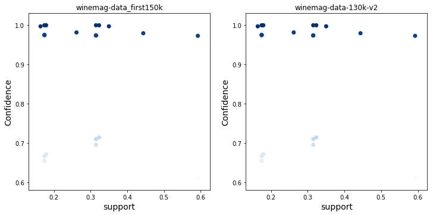

```python
#对规则进行可视化，使用散点图和盒图
#散点图
plt.figure(figsize=(12,12))
ax1 = plt.subplot(2,2,1)
ax2 = plt.subplot(2,2,2)
#库1
support,confidence=getnum(rules)
plt.sca(ax1)
ax1.scatter(support,confidence,c=confidence,cmap='Blues')
plt.title("winemag-data_first150k")
plt.xlabel("support", fontsize=14)
plt.ylabel("Confidence", fontsize=14)

#库2
support2,confidence2=getnum(rules2)
plt.sca(ax2)
ax2.scatter(support,confidence,c=confidence,cmap='Blues')
plt.title("winemag-data-130k-v2")
plt.xlabel("support", fontsize=14)
plt.ylabel("Confidence", fontsize=14)

plt.show()
```

用了渐变色，直观看上去深颜色表示confidence高，从图中可以看出两个库挖掘出来的规则都有许多规则的置信度都在0.9以上

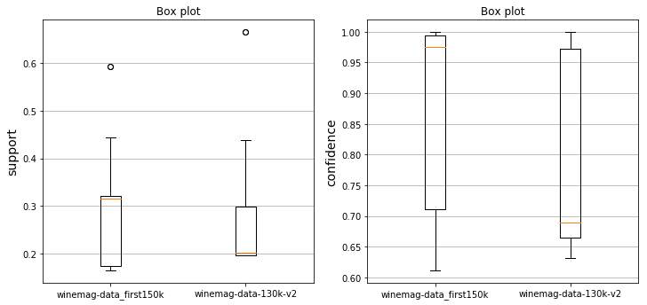

```python
plt.figure(figsize=(12,12))
ax1 = plt.subplot(2,2,1)
ax2 = plt.subplot(2,2,2)
#库1
plt.sca(ax1)
title=("Box plot")
support3=[support,support2]
ax1.boxplot(support3)
ax1.yaxis.grid(True)
plt.title(title)
plt.xticks([1,2],["winemag-data_first150k","winemag-data-130k-v2"])
plt.ylabel("support", fontsize=14)

plt.sca(ax2)
title=("Box plot")
confidence3=[confidence,confidence2]
ax2.boxplot(confidence3)
ax2.yaxis.grid(True)
plt.title(title)
plt.xticks([1,2],["winemag-data_first150k","winemag-data-130k-v2"])
plt.ylabel("confidence", fontsize=14)
```

盒图绘制的直观结果：support的盒图两个库抖存在离群值，而confidence则无离群值，但其拉的比较长。